# Risk Factor Analysis

## Outcome Variable

**Outcome Variable:** stunted

## Predictor Variables

**Intervention Variable:** impfloor

**Adjustment Set:**

- arm
- sex
- W_mage
- meducyrs
- feducyrs
- hhwealth_quart
- hfoodsec
- W_mhtcm
- W_mwtkg
- W_mbmi
- W_nrooms
- W_nchldlt5
- W_parity
- impsan
- safeh20
- delta_W_mage
- delta_meducyrs
- delta_feducyrs
- delta_hhwealth_quart
- delta_hfoodsec
- delta_W_mhtcm
- delta_W_mwtkg
- delta_W_mbmi
- delta_W_nrooms
- delta_W_nchldlt5
- delta_W_parity
- delta_impsan
- delta_safeh20

## Stratifying Variables

The analysis was stratified on these variable(s):

- agecat
- studyid
- country

## Data Summary

| agecat | studyid | country | impfloor | stunted | n_cell | n |
| --- | --- | --- | --- | --- | --- | --- |
| Birth | ki0047075b-MAL-ED | BANGLADESH | 1 | 0 | 161 | 213 |
| Birth | ki0047075b-MAL-ED | BANGLADESH | 1 | 1 | 35 | 213 |
| Birth | ki0047075b-MAL-ED | BANGLADESH | 0 | 0 | 15 | 213 |
| Birth | ki0047075b-MAL-ED | BANGLADESH | 0 | 1 | 2 | 213 |
| Birth | ki0047075b-MAL-ED | BRAZIL | 1 | 0 | 49 | 60 |
| Birth | ki0047075b-MAL-ED | BRAZIL | 1 | 1 | 9 | 60 |
| Birth | ki0047075b-MAL-ED | BRAZIL | 0 | 0 | 2 | 60 |
| Birth | ki0047075b-MAL-ED | BRAZIL | 0 | 1 | 0 | 60 |
| Birth | ki0047075b-MAL-ED | INDIA | 1 | 0 | 27 | 41 |
| Birth | ki0047075b-MAL-ED | INDIA | 1 | 1 | 8 | 41 |
| Birth | ki0047075b-MAL-ED | INDIA | 0 | 0 | 6 | 41 |
| Birth | ki0047075b-MAL-ED | INDIA | 0 | 1 | 0 | 41 |
| Birth | ki0047075b-MAL-ED | NEPAL | 1 | 0 | 8 | 25 |
| Birth | ki0047075b-MAL-ED | NEPAL | 1 | 1 | 1 | 25 |
| Birth | ki0047075b-MAL-ED | NEPAL | 0 | 0 | 15 | 25 |
| Birth | ki0047075b-MAL-ED | NEPAL | 0 | 1 | 1 | 25 |
| Birth | ki0047075b-MAL-ED | PERU | 1 | 0 | 30 | 215 |
| Birth | ki0047075b-MAL-ED | PERU | 1 | 1 | 9 | 215 |
| Birth | ki0047075b-MAL-ED | PERU | 0 | 0 | 159 | 215 |
| Birth | ki0047075b-MAL-ED | PERU | 0 | 1 | 17 | 215 |
| Birth | ki0047075b-MAL-ED | SOUTH AFRICA | 1 | 0 | 80 | 96 |
| Birth | ki0047075b-MAL-ED | SOUTH AFRICA | 1 | 1 | 7 | 96 |
| Birth | ki0047075b-MAL-ED | SOUTH AFRICA | 0 | 0 | 8 | 96 |
| Birth | ki0047075b-MAL-ED | SOUTH AFRICA | 0 | 1 | 1 | 96 |
| Birth | ki0047075b-MAL-ED | TANZANIA, UNITED REPUBLIC OF | 1 | 0 | 5 | 119 |
| Birth | ki0047075b-MAL-ED | TANZANIA, UNITED REPUBLIC OF | 1 | 1 | 2 | 119 |
| Birth | ki0047075b-MAL-ED | TANZANIA, UNITED REPUBLIC OF | 0 | 0 | 93 | 119 |
| Birth | ki0047075b-MAL-ED | TANZANIA, UNITED REPUBLIC OF | 0 | 1 | 19 | 119 |
| Birth | ki1000108-CMC-V-BCS-2002 | INDIA | 1 | 0 | 58 | 72 |
| Birth | ki1000108-CMC-V-BCS-2002 | INDIA | 1 | 1 | 14 | 72 |

[output cut: 162 more lines]

The following strata were considered:

- agecat: 24 months, studyid: ki0047075b-MAL-ED, country: BANGLADESH
- agecat: 24 months, studyid: ki0047075b-MAL-ED, country: BRAZIL
- agecat: 24 months, studyid: ki0047075b-MAL-ED, country: INDIA
- agecat: 24 months, studyid: ki0047075b-MAL-ED, country: NEPAL
- agecat: 24 months, studyid: ki0047075b-MAL-ED, country: PERU
- agecat: 24 months, studyid: ki0047075b-MAL-ED, country: SOUTH AFRICA
- agecat: 24 months, studyid: ki0047075b-MAL-ED, country: TANZANIA, UNITED REPUBLIC OF
- agecat: 24 months, studyid: ki1000108-CMC-V-BCS-2002, country: INDIA
- agecat: 24 months, studyid: ki1000108-IRC, country: INDIA
- agecat: 24 months, studyid: ki1017093-NIH-Birth, country: BANGLADESH
- agecat: 24 months, studyid: ki1017093b-PROVIDE, country: BANGLADESH
- agecat: 24 months, studyid: ki1017093c-NIH-Crypto, country: BANGLADESH
- agecat: 24 months, studyid: ki1113344-GMS-Nepal, country: NEPAL
- agecat: 24 months, studyid: ki1114097-CONTENT, country: PERU
- agecat: 24 months, studyid: kiGH5241-JiVitA-3, country: BANGLADESH
- agecat: 24 months, studyid: kiGH5241-JiVitA-4, country: BANGLADESH
- agecat: 6 months, studyid: ki0047075b-MAL-ED, country: BANGLADESH
- agecat: 6 months, studyid: ki0047075b-MAL-ED, country: BRAZIL
- agecat: 6 months, studyid: ki0047075b-MAL-ED, country: INDIA
- agecat: 6 months, studyid: ki0047075b-MAL-ED, country: NEPAL
- agecat: 6 months, studyid: ki0047075b-MAL-ED, country: PERU
- agecat: 6 months, studyid: ki0047075b-MAL-ED, country: SOUTH AFRICA
- agecat: 6 months, studyid: ki0047075b-MAL-ED, country: TANZANIA, UNITED REPUBLIC OF
- agecat: 6 months, studyid: ki1000108-CMC-V-BCS-2002, country: INDIA
- agecat: 6 months, studyid: ki1000108-IRC, country: INDIA
- agecat: 6 months, studyid: ki1017093-NIH-Birth, country: BANGLADESH
- agecat: 6 months, studyid: ki1017093b-PROVIDE, country: BANGLADESH
- agecat: 6 months, studyid: ki1017093c-NIH-Crypto, country: BANGLADESH
- agecat: 6 months, studyid: ki1113344-GMS-Nepal, country: NEPAL
- agecat: 6 months, studyid: ki1114097-CONTENT, country: PERU
- agecat: 6 months, studyid: kiGH5241-JiVitA-3, country: BANGLADESH
- agecat: 6 months, studyid: kiGH5241-JiVitA-4, country: BANGLADESH
- agecat: Birth, studyid: ki0047075b-MAL-ED, country: BANGLADESH
- agecat: Birth, studyid: ki0047075b-MAL-ED, country: BRAZIL
- agecat: Birth, studyid: ki0047075b-MAL-ED, country: INDIA
- agecat: Birth, studyid: ki0047075b-MAL-ED, country: NEPAL
- agecat: Birth, studyid: ki0047075b-MAL-ED, country: PERU
- agecat: Birth, studyid: ki0047075b-MAL-ED, country: SOUTH AFRICA
- agecat: Birth, studyid: ki0047075b-MAL-ED, country: TANZANIA, UNITED REPUBLIC OF
- agecat: Birth, studyid: ki1000108-CMC-V-BCS-2002, country: INDIA
- agecat: Birth, studyid: ki1000108-IRC, country: INDIA
- agecat: Birth, studyid: ki1017093-NIH-Birth, country: BANGLADESH
- agecat: Birth, studyid: ki1017093b-PROVIDE, country: BANGLADESH
- agecat: Birth, studyid: ki1017093c-NIH-Crypto, country: BANGLADESH
- agecat: Birth, studyid: ki1113344-GMS-Nepal, country: NEPAL
- agecat: Birth, studyid: ki1114097-CONTENT, country: PERU
- agecat: Birth, studyid: kiGH5241-JiVitA-3, country: BANGLADESH
- agecat: Birth, studyid: kiGH5241-JiVitA-4, country: BANGLADESH

### Dropped Strata

Some strata were dropped due to rare outcomes:

- agecat: Birth, studyid: ki0047075b-MAL-ED, country: BANGLADESH
- agecat: Birth, studyid: ki0047075b-MAL-ED, country: BRAZIL
- agecat: Birth, studyid: ki0047075b-MAL-ED, country: INDIA
- agecat: Birth, studyid: ki0047075b-MAL-ED, country: NEPAL
- agecat: Birth, studyid: ki0047075b-MAL-ED, country: SOUTH AFRICA
- agecat: Birth, studyid: ki0047075b-MAL-ED, country: TANZANIA, UNITED REPUBLIC OF
- agecat: Birth, studyid: ki1000108-CMC-V-BCS-2002, country: INDIA
- agecat: Birth, studyid: ki1000108-IRC, country: INDIA
- agecat: Birth, studyid: ki1017093b-PROVIDE, country: BANGLADESH
- agecat: Birth, studyid: ki1114097-CONTENT, country: PERU
- agecat: 6 months, studyid: ki0047075b-MAL-ED, country: BANGLADESH
- agecat: 6 months, studyid: ki0047075b-MAL-ED, country: BRAZIL
- agecat: 6 months, studyid: ki0047075b-MAL-ED, country: INDIA
- agecat: 6 months, studyid: ki0047075b-MAL-ED, country: SOUTH AFRICA
- agecat: 6 months, studyid: ki0047075b-MAL-ED, country: TANZANIA, UNITED REPUBLIC OF
- agecat: 6 months, studyid: ki1000108-CMC-V-BCS-2002, country: INDIA
- agecat: 6 months, studyid: ki1000108-IRC, country: INDIA
- agecat: 6 months, studyid: ki1114097-CONTENT, country: PERU
- agecat: 24 months, studyid: ki0047075b-MAL-ED, country: BRAZIL
- agecat: 24 months, studyid: ki0047075b-MAL-ED, country: TANZANIA, UNITED REPUBLIC OF
- agecat: 24 months, studyid: ki1000108-CMC-V-BCS-2002, country: INDIA
- agecat: 24 months, studyid: ki1000108-IRC, country: INDIA
- agecat: 24 months, studyid: ki1114097-CONTENT, country: PERU

## Methods Detail

We’re interested in the causal parameters $E[Y_a]$ for all values of $a \in \mathcal{A}$. These parameters represent the mean outcome if, possibly contrary to fact, we intervened to set all units to have $A=a$. Under the randomization and positivity assumptions, these are identified by the statistical parameters $\psi_a=E_W[E_{Y|A,W}(Y|A=a,W)]$. In addition, we’re interested in the mean of $Y$, $E[Y]$ under no intervention (the observed mean). We will estimate these parameters by using SuperLearner to fit the relevant likelihood factors – $E_{Y|A,W}(Y|A=a,W)$ and $p(A=a|W)$, and then updating our likelihood fit using a joint TMLE.

For unadjusted analyses ($W=\{\}$), initial likelihoods were estimated using Lrnr_glm to estimate the simple $E(Y|A)$ and Lrnr_mean to estimate $p(A)$. For adjusted analyses, a small library containing Lrnr_glmnet, Lrnr_xgboost, and Lrnr_mean was used.

Having estimated these parameters, we will then use the delta method to estimate relative risks and attributable risks relative to a prespecified baseline level of $A$.

# Results Detail

## Results Plots

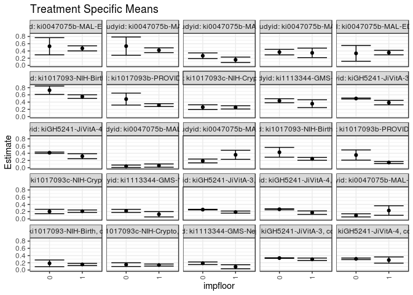

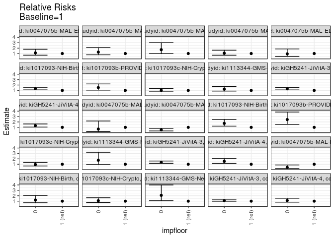

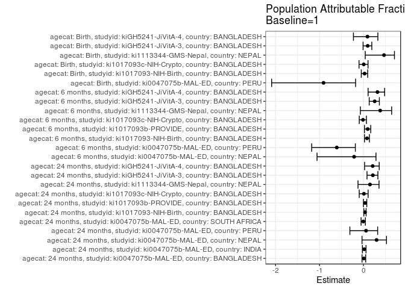

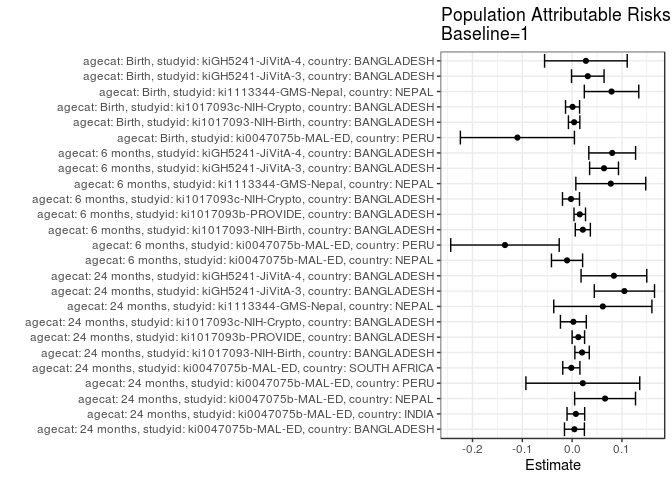

## Results Table

### Parameter: TSM

| agecat | studyid | country | intervention_level | baseline_level | estimate | ci_lower | ci_upper |
| --- | --- | --- | --- | --- | --- | --- | --- |
| Birth | ki0047075b-MAL-ED | PERU | 1 | NA | 0.2307692 | 0.0982297 | 0.3633088 |
| Birth | ki0047075b-MAL-ED | PERU | 0 | NA | 0.0965909 | 0.0528473 | 0.1403345 |
| Birth | ki1017093-NIH-Birth | BANGLADESH | 1 | NA | 0.1529935 | 0.1224868 | 0.1835003 |
| Birth | ki1017093-NIH-Birth | BANGLADESH | 0 | NA | 0.1847789 | 0.0925706 | 0.2769872 |
| Birth | ki1017093c-NIH-Crypto | BANGLADESH | 1 | NA | 0.1371072 | 0.1086306 | 0.1655838 |
| Birth | ki1017093c-NIH-Crypto | BANGLADESH | 0 | NA | 0.1487539 | 0.0967399 | 0.2007679 |
| Birth | ki1113344-GMS-Nepal | NEPAL | 1 | NA | 0.0900000 | 0.0338578 | 0.1461422 |
| Birth | ki1113344-GMS-Nepal | NEPAL | 0 | NA | 0.1869369 | 0.1506403 | 0.2232335 |
| Birth | kiGH5241-JiVitA-3 | BANGLADESH | 1 | NA | 0.2976662 | 0.2643959 | 0.3309364 |
| Birth | kiGH5241-JiVitA-3 | BANGLADESH | 0 | NA | 0.3303231 | 0.3227385 | 0.3379078 |
| Birth | kiGH5241-JiVitA-4 | BANGLADESH | 1 | NA | 0.2759034 | 0.1899253 | 0.3618814 |
| Birth | kiGH5241-JiVitA-4 | BANGLADESH | 0 | NA | 0.3093121 | 0.2874131 | 0.3312111 |
| 6 months | ki0047075b-MAL-ED | NEPAL | 1 | NA | 0.0582524 | 0.0129205 | 0.1035843 |
| 6 months | ki0047075b-MAL-ED | NEPAL | 0 | NA | 0.0396825 | 0.0055223 | 0.0738427 |
| 6 months | ki0047075b-MAL-ED | PERU | 1 | NA | 0.3570396 | 0.2310060 | 0.4830732 |
| 6 months | ki0047075b-MAL-ED | PERU | 0 | NA | 0.1869080 | 0.1339152 | 0.2399009 |
| 6 months | ki1017093-NIH-Birth | BANGLADESH | 1 | NA | 0.2458163 | 0.2073539 | 0.2842787 |
| 6 months | ki1017093-NIH-Birth | BANGLADESH | 0 | NA | 0.4265560 | 0.2906853 | 0.5624268 |
| 6 months | ki1017093b-PROVIDE | BANGLADESH | 1 | NA | 0.1436189 | 0.1144612 | 0.1727767 |
| 6 months | ki1017093b-PROVIDE | BANGLADESH | 0 | NA | 0.3507519 | 0.2097699 | 0.4917340 |
| 6 months | ki1017093c-NIH-Crypto | BANGLADESH | 1 | NA | 0.2120678 | 0.1777156 | 0.2464199 |
| 6 months | ki1017093c-NIH-Crypto | BANGLADESH | 0 | NA | 0.2036719 | 0.1432639 | 0.2640799 |
| 6 months | ki1113344-GMS-Nepal | NEPAL | 1 | NA | 0.1264751 | 0.0528931 | 0.2000571 |
| 6 months | ki1113344-GMS-Nepal | NEPAL | 0 | NA | 0.2204820 | 0.1777178 | 0.2632462 |
| 6 months | kiGH5241-JiVitA-3 | BANGLADESH | 1 | NA | 0.1873549 | 0.1579196 | 0.2167902 |
| 6 months | kiGH5241-JiVitA-3 | BANGLADESH | 0 | NA | 0.2559326 | 0.2475718 | 0.2642934 |
| 6 months | kiGH5241-JiVitA-4 | BANGLADESH | 1 | NA | 0.1720344 | 0.1238631 | 0.2202058 |
| 6 months | kiGH5241-JiVitA-4 | BANGLADESH | 0 | NA | 0.2649690 | 0.2494487 | 0.2804893 |
| 24 months | ki0047075b-MAL-ED | BANGLADESH | 1 | NA | 0.4717949 | 0.4015628 | 0.5420269 |
| 24 months | ki0047075b-MAL-ED | BANGLADESH | 0 | NA | 0.5294118 | 0.2915812 | 0.7672423 |
| 24 months | ki0047075b-MAL-ED | INDIA | 1 | NA | 0.4198113 | 0.3532303 | 0.4863924 |
| 24 months | ki0047075b-MAL-ED | INDIA | 0 | NA | 0.5333333 | 0.2803080 | 0.7863586 |
| 24 months | ki0047075b-MAL-ED | NEPAL | 1 | NA | 0.1555938 | 0.0815483 | 0.2296394 |
| 24 months | ki0047075b-MAL-ED | NEPAL | 0 | NA | 0.2665785 | 0.1878491 | 0.3453079 |
| 24 months | ki0047075b-MAL-ED | PERU | 1 | NA | 0.3466895 | 0.2151092 | 0.4782699 |
| 24 months | ki0047075b-MAL-ED | PERU | 0 | NA | 0.3675438 | 0.2905589 | 0.4445287 |
| 24 months | ki0047075b-MAL-ED | SOUTH AFRICA | 1 | NA | 0.3545455 | 0.2911994 | 0.4178915 |
| 24 months | ki0047075b-MAL-ED | SOUTH AFRICA | 0 | NA | 0.3333333 | 0.1151006 | 0.5515661 |
| 24 months | ki1017093-NIH-Birth | BANGLADESH | 1 | NA | 0.5514596 | 0.5013425 | 0.6015767 |
| 24 months | ki1017093-NIH-Birth | BANGLADESH | 0 | NA | 0.7291020 | 0.6134504 | 0.8447537 |
| 24 months | ki1017093b-PROVIDE | BANGLADESH | 1 | NA | 0.3162282 | 0.2765732 | 0.3558832 |
| 24 months | ki1017093b-PROVIDE | BANGLADESH | 0 | NA | 0.4832299 | 0.3176679 | 0.6487920 |
| 24 months | ki1017093c-NIH-Crypto | BANGLADESH | 1 | NA | 0.2543045 | 0.2088289 | 0.2997801 |
| 24 months | ki1017093c-NIH-Crypto | BANGLADESH | 0 | NA | 0.2595525 | 0.1933514 | 0.3257536 |
| 24 months | ki1113344-GMS-Nepal | NEPAL | 1 | NA | 0.3554803 | 0.2472985 | 0.4636621 |
| 24 months | ki1113344-GMS-Nepal | NEPAL | 0 | NA | 0.4372117 | 0.3811430 | 0.4932805 |
| 24 months | kiGH5241-JiVitA-3 | BANGLADESH | 1 | NA | 0.3860557 | 0.3243991 | 0.4477123 |
| 24 months | kiGH5241-JiVitA-3 | BANGLADESH | 0 | NA | 0.4992870 | 0.4857423 | 0.5128317 |
| 24 months | kiGH5241-JiVitA-4 | BANGLADESH | 1 | NA | 0.3170959 | 0.2484581 | 0.3857336 |
| 24 months | kiGH5241-JiVitA-4 | BANGLADESH | 0 | NA | 0.4146209 | 0.3965067 | 0.4327351 |

### Parameter: E(Y)

| agecat | studyid | country | intervention_level | baseline_level | estimate | ci_lower | ci_upper |
| --- | --- | --- | --- | --- | --- | --- | --- |
| Birth | ki0047075b-MAL-ED | PERU | NA | NA | 0.1209302 | 0.0772464 | 0.1646140 |
| Birth | ki1017093-NIH-Birth | BANGLADESH | NA | NA | 0.1570248 | 0.1280099 | 0.1860397 |
| Birth | ki1017093c-NIH-Crypto | BANGLADESH | NA | NA | 0.1379781 | 0.1129774 | 0.1629789 |
| Birth | ki1113344-GMS-Nepal | NEPAL | NA | NA | 0.1691176 | 0.1375885 | 0.2006468 |
| Birth | kiGH5241-JiVitA-3 | BANGLADESH | NA | NA | 0.3291218 | 0.3217144 | 0.3365293 |
| Birth | kiGH5241-JiVitA-4 | BANGLADESH | NA | NA | 0.3035461 | 0.2835868 | 0.3235054 |
| 6 months | ki0047075b-MAL-ED | NEPAL | NA | NA | 0.0480349 | 0.0202781 | 0.0757918 |
| 6 months | ki0047075b-MAL-ED | PERU | NA | NA | 0.2222222 | 0.1725409 | 0.2719036 |
| 6 months | ki1017093-NIH-Birth | BANGLADESH | NA | NA | 0.2672897 | 0.2297549 | 0.3048246 |
| 6 months | ki1017093b-PROVIDE | BANGLADESH | NA | NA | 0.1589404 | 0.1297581 | 0.1881227 |
| 6 months | ki1017093c-NIH-Crypto | BANGLADESH | NA | NA | 0.2097902 | 0.1799252 | 0.2396552 |
| 6 months | ki1113344-GMS-Nepal | NEPAL | NA | NA | 0.2040816 | 0.1664236 | 0.2417397 |
| 6 months | kiGH5241-JiVitA-3 | BANGLADESH | NA | NA | 0.2514160 | 0.2432636 | 0.2595684 |
| 6 months | kiGH5241-JiVitA-4 | BANGLADESH | NA | NA | 0.2524876 | 0.2384257 | 0.2665494 |
| 24 months | ki0047075b-MAL-ED | BANGLADESH | NA | NA | 0.4764151 | 0.4090254 | 0.5438047 |
| 24 months | ki0047075b-MAL-ED | INDIA | NA | NA | 0.4273128 | 0.3628178 | 0.4918077 |
| 24 months | ki0047075b-MAL-ED | NEPAL | NA | NA | 0.2217195 | 0.1668277 | 0.2766112 |
| 24 months | ki0047075b-MAL-ED | PERU | NA | NA | 0.3681592 | 0.3013164 | 0.4350020 |
| 24 months | ki0047075b-MAL-ED | SOUTH AFRICA | NA | NA | 0.3529412 | 0.2921001 | 0.4137823 |
| 24 months | ki1017093-NIH-Birth | BANGLADESH | NA | NA | 0.5714286 | 0.5244353 | 0.6184219 |
| 24 months | ki1017093b-PROVIDE | BANGLADESH | NA | NA | 0.3287197 | 0.2903909 | 0.3670485 |
| 24 months | ki1017093c-NIH-Crypto | BANGLADESH | NA | NA | 0.2568093 | 0.2190047 | 0.2946140 |
| 24 months | ki1113344-GMS-Nepal | NEPAL | NA | NA | 0.4171123 | 0.3670728 | 0.4671518 |
| 24 months | kiGH5241-JiVitA-3 | BANGLADESH | NA | NA | 0.4909978 | 0.4779033 | 0.5040923 |
| 24 months | kiGH5241-JiVitA-4 | BANGLADESH | NA | NA | 0.4009692 | 0.3839829 | 0.4179556 |

### Parameter: RR

| agecat | studyid | country | intervention_level | baseline_level | estimate | ci_lower | ci_upper |
| --- | --- | --- | --- | --- | --- | --- | --- |
| Birth | ki0047075b-MAL-ED | PERU | 1 | 1 | 1.0000000 | 1.0000000 | 1.0000000 |
| Birth | ki0047075b-MAL-ED | PERU | 0 | 1 | 0.4185606 | 0.2014240 | 0.8697720 |
| Birth | ki1017093-NIH-Birth | BANGLADESH | 1 | 1 | 1.0000000 | 1.0000000 | 1.0000000 |
| Birth | ki1017093-NIH-Birth | BANGLADESH | 0 | 1 | 1.2077561 | 0.7060582 | 2.0659414 |
| Birth | ki1017093c-NIH-Crypto | BANGLADESH | 1 | 1 | 1.0000000 | 1.0000000 | 1.0000000 |
| Birth | ki1017093c-NIH-Crypto | BANGLADESH | 0 | 1 | 1.0849455 | 0.7225708 | 1.6290539 |
| Birth | ki1113344-GMS-Nepal | NEPAL | 1 | 1 | 1.0000000 | 1.0000000 | 1.0000000 |
| Birth | ki1113344-GMS-Nepal | NEPAL | 0 | 1 | 2.0770768 | 1.0807332 | 3.9919641 |
| Birth | kiGH5241-JiVitA-3 | BANGLADESH | 1 | 1 | 1.0000000 | 1.0000000 | 1.0000000 |
| Birth | kiGH5241-JiVitA-3 | BANGLADESH | 0 | 1 | 1.1097101 | 0.9909770 | 1.2426690 |
| Birth | kiGH5241-JiVitA-4 | BANGLADESH | 1 | 1 | 1.0000000 | 1.0000000 | 1.0000000 |
| Birth | kiGH5241-JiVitA-4 | BANGLADESH | 0 | 1 | 1.1210883 | 0.8146193 | 1.5428545 |
| 6 months | ki0047075b-MAL-ED | NEPAL | 1 | 1 | 1.0000000 | 1.0000000 | 1.0000000 |
| 6 months | ki0047075b-MAL-ED | NEPAL | 0 | 1 | 0.6812169 | 0.2134571 | 2.1740031 |
| 6 months | ki0047075b-MAL-ED | PERU | 1 | 1 | 1.0000000 | 1.0000000 | 1.0000000 |
| 6 months | ki0047075b-MAL-ED | PERU | 0 | 1 | 0.5234939 | 0.3336048 | 0.8214685 |
| 6 months | ki1017093-NIH-Birth | BANGLADESH | 1 | 1 | 1.0000000 | 1.0000000 | 1.0000000 |
| 6 months | ki1017093-NIH-Birth | BANGLADESH | 0 | 1 | 1.7352633 | 1.2202274 | 2.4676864 |
| 6 months | ki1017093b-PROVIDE | BANGLADESH | 1 | 1 | 1.0000000 | 1.0000000 | 1.0000000 |
| 6 months | ki1017093b-PROVIDE | BANGLADESH | 0 | 1 | 2.4422405 | 1.5568761 | 3.8310939 |
| 6 months | ki1017093c-NIH-Crypto | BANGLADESH | 1 | 1 | 1.0000000 | 1.0000000 | 1.0000000 |
| 6 months | ki1017093c-NIH-Crypto | BANGLADESH | 0 | 1 | 0.9604094 | 0.6853530 | 1.3458558 |
| 6 months | ki1113344-GMS-Nepal | NEPAL | 1 | 1 | 1.0000000 | 1.0000000 | 1.0000000 |
| 6 months | ki1113344-GMS-Nepal | NEPAL | 0 | 1 | 1.7432832 | 0.9438838 | 3.2197147 |
| 6 months | kiGH5241-JiVitA-3 | BANGLADESH | 1 | 1 | 1.0000000 | 1.0000000 | 1.0000000 |
| 6 months | kiGH5241-JiVitA-3 | BANGLADESH | 0 | 1 | 1.3660310 | 1.1656018 | 1.6009246 |
| 6 months | kiGH5241-JiVitA-4 | BANGLADESH | 1 | 1 | 1.0000000 | 1.0000000 | 1.0000000 |
| 6 months | kiGH5241-JiVitA-4 | BANGLADESH | 0 | 1 | 1.5402092 | 1.1568660 | 2.0505784 |
| 24 months | ki0047075b-MAL-ED | BANGLADESH | 1 | 1 | 1.0000000 | 1.0000000 | 1.0000000 |
| 24 months | ki0047075b-MAL-ED | BANGLADESH | 0 | 1 | 1.1221228 | 0.6990487 | 1.8012472 |
| 24 months | ki0047075b-MAL-ED | INDIA | 1 | 1 | 1.0000000 | 1.0000000 | 1.0000000 |
| 24 months | ki0047075b-MAL-ED | INDIA | 0 | 1 | 1.2704120 | 0.7703668 | 2.0950365 |
| 24 months | ki0047075b-MAL-ED | NEPAL | 1 | 1 | 1.0000000 | 1.0000000 | 1.0000000 |
| 24 months | ki0047075b-MAL-ED | NEPAL | 0 | 1 | 1.7132973 | 0.9765898 | 3.0057528 |
| 24 months | ki0047075b-MAL-ED | PERU | 1 | 1 | 1.0000000 | 1.0000000 | 1.0000000 |
| 24 months | ki0047075b-MAL-ED | PERU | 0 | 1 | 1.0601527 | 0.6920639 | 1.6240172 |
| 24 months | ki0047075b-MAL-ED | SOUTH AFRICA | 1 | 1 | 1.0000000 | 1.0000000 | 1.0000000 |
| 24 months | ki0047075b-MAL-ED | SOUTH AFRICA | 0 | 1 | 0.9401709 | 0.4769548 | 1.8532602 |
| 24 months | ki1017093-NIH-Birth | BANGLADESH | 1 | 1 | 1.0000000 | 1.0000000 | 1.0000000 |
| 24 months | ki1017093-NIH-Birth | BANGLADESH | 0 | 1 | 1.3221313 | 1.1055544 | 1.5811354 |
| 24 months | ki1017093b-PROVIDE | BANGLADESH | 1 | 1 | 1.0000000 | 1.0000000 | 1.0000000 |
| 24 months | ki1017093b-PROVIDE | BANGLADESH | 0 | 1 | 1.5281053 | 1.0609022 | 2.2010566 |
| 24 months | ki1017093c-NIH-Crypto | BANGLADESH | 1 | 1 | 1.0000000 | 1.0000000 | 1.0000000 |
| 24 months | ki1017093c-NIH-Crypto | BANGLADESH | 0 | 1 | 1.0206364 | 0.7513910 | 1.3863604 |
| 24 months | ki1113344-GMS-Nepal | NEPAL | 1 | 1 | 1.0000000 | 1.0000000 | 1.0000000 |
| 24 months | ki1113344-GMS-Nepal | NEPAL | 0 | 1 | 1.2299183 | 0.8848228 | 1.7096067 |
| 24 months | kiGH5241-JiVitA-3 | BANGLADESH | 1 | 1 | 1.0000000 | 1.0000000 | 1.0000000 |
| 24 months | kiGH5241-JiVitA-3 | BANGLADESH | 0 | 1 | 1.2933031 | 1.1012373 | 1.5188669 |
| 24 months | kiGH5241-JiVitA-4 | BANGLADESH | 1 | 1 | 1.0000000 | 1.0000000 | 1.0000000 |
| 24 months | kiGH5241-JiVitA-4 | BANGLADESH | 0 | 1 | 1.3075569 | 1.0509757 | 1.6267789 |

### Parameter: PAR

| agecat | studyid | country | intervention_level | baseline_level | estimate | ci_lower | ci_upper |
| --- | --- | --- | --- | --- | --- | --- | --- |
| Birth | ki0047075b-MAL-ED | PERU | 1 | NA | -0.1098390 | -0.2243028 | 0.0046248 |
| Birth | ki1017093-NIH-Birth | BANGLADESH | 1 | NA | 0.0040313 | -0.0074170 | 0.0154795 |
| Birth | ki1017093c-NIH-Crypto | BANGLADESH | 1 | NA | 0.0008709 | -0.0132281 | 0.0149699 |
| Birth | ki1113344-GMS-Nepal | NEPAL | 1 | NA | 0.0791176 | 0.0244621 | 0.1337732 |
| Birth | kiGH5241-JiVitA-3 | BANGLADESH | 1 | NA | 0.0314557 | -0.0011868 | 0.0640981 |
| Birth | kiGH5241-JiVitA-4 | BANGLADESH | 1 | NA | 0.0276427 | -0.0553187 | 0.1106041 |
| 6 months | ki0047075b-MAL-ED | NEPAL | 1 | NA | -0.0102175 | -0.0414719 | 0.0210369 |
| 6 months | ki0047075b-MAL-ED | PERU | 1 | NA | -0.1348174 | -0.2436793 | -0.0259555 |
| 6 months | ki1017093-NIH-Birth | BANGLADESH | 1 | NA | 0.0214734 | 0.0063374 | 0.0366094 |
| 6 months | ki1017093b-PROVIDE | BANGLADESH | 1 | NA | 0.0153215 | 0.0037479 | 0.0268950 |
| 6 months | ki1017093c-NIH-Crypto | BANGLADESH | 1 | NA | -0.0022776 | -0.0193474 | 0.0147923 |
| 6 months | ki1113344-GMS-Nepal | NEPAL | 1 | NA | 0.0776065 | 0.0074530 | 0.1477600 |
| 6 months | kiGH5241-JiVitA-3 | BANGLADESH | 1 | NA | 0.0640611 | 0.0350792 | 0.0930429 |
| 6 months | kiGH5241-JiVitA-4 | BANGLADESH | 1 | NA | 0.0804531 | 0.0335149 | 0.1273914 |
| 24 months | ki0047075b-MAL-ED | BANGLADESH | 1 | NA | 0.0046202 | -0.0153770 | 0.0246175 |
| 24 months | ki0047075b-MAL-ED | INDIA | 1 | NA | 0.0075015 | -0.0101741 | 0.0251770 |
| 24 months | ki0047075b-MAL-ED | NEPAL | 1 | NA | 0.0661256 | 0.0050286 | 0.1272227 |
| 24 months | ki0047075b-MAL-ED | PERU | 1 | NA | 0.0214697 | -0.0927670 | 0.1357063 |
| 24 months | ki0047075b-MAL-ED | SOUTH AFRICA | 1 | NA | -0.0016043 | -0.0188054 | 0.0155968 |
| 24 months | ki1017093-NIH-Birth | BANGLADESH | 1 | NA | 0.0199689 | 0.0054860 | 0.0344519 |
| 24 months | ki1017093b-PROVIDE | BANGLADESH | 1 | NA | 0.0124915 | -0.0000137 | 0.0249968 |
| 24 months | ki1017093c-NIH-Crypto | BANGLADESH | 1 | NA | 0.0025048 | -0.0234500 | 0.0284597 |
| 24 months | ki1113344-GMS-Nepal | NEPAL | 1 | NA | 0.0616320 | -0.0368703 | 0.1601343 |
| 24 months | kiGH5241-JiVitA-3 | BANGLADESH | 1 | NA | 0.1049421 | 0.0445327 | 0.1653515 |
| 24 months | kiGH5241-JiVitA-4 | BANGLADESH | 1 | NA | 0.0838734 | 0.0179391 | 0.1498076 |

### Parameter: PAF

| agecat | studyid | country | intervention_level | baseline_level | estimate | ci_lower | ci_upper |
| --- | --- | --- | --- | --- | --- | --- | --- |
| Birth | ki0047075b-MAL-ED | PERU | 1 | NA | -0.9082840 | -2.0890152 | -0.1788701 |
| Birth | ki1017093-NIH-Birth | BANGLADESH | 1 | NA | 0.0256727 | -0.0498728 | 0.0957823 |
| Birth | ki1017093c-NIH-Crypto | BANGLADESH | 1 | NA | 0.0063119 | -0.1012935 | 0.1034033 |
| Birth | ki1113344-GMS-Nepal | NEPAL | 1 | NA | 0.4678260 | 0.0402469 | 0.7049146 |
| Birth | kiGH5241-JiVitA-3 | BANGLADESH | 1 | NA | 0.0955745 | -0.0092075 | 0.1894774 |
| Birth | kiGH5241-JiVitA-4 | BANGLADESH | 1 | NA | 0.0910659 | -0.2281399 | 0.3273069 |
| 6 months | ki0047075b-MAL-ED | NEPAL | 1 | NA | -0.2127096 | -1.0563292 | 0.2848107 |
| 6 months | ki0047075b-MAL-ED | PERU | 1 | NA | -0.6066782 | -1.1782897 | -0.1850650 |
| 6 months | ki1017093-NIH-Birth | BANGLADESH | 1 | NA | 0.0803375 | 0.0224115 | 0.1348311 |
| 6 months | ki1017093b-PROVIDE | BANGLADESH | 1 | NA | 0.0963976 | 0.0220932 | 0.1650562 |
| 6 months | ki1017093c-NIH-Crypto | BANGLADESH | 1 | NA | -0.0108564 | -0.0956081 | 0.0673393 |
| 6 months | ki1113344-GMS-Nepal | NEPAL | 1 | NA | 0.3802718 | -0.0702286 | 0.6411392 |
| 6 months | kiGH5241-JiVitA-3 | BANGLADESH | 1 | NA | 0.2548011 | 0.1306037 | 0.3612564 |
| 6 months | kiGH5241-JiVitA-4 | BANGLADESH | 1 | NA | 0.3186420 | 0.1052131 | 0.4811628 |
| 24 months | ki0047075b-MAL-ED | BANGLADESH | 1 | NA | 0.0096979 | -0.0331976 | 0.0508125 |
| 24 months | ki0047075b-MAL-ED | INDIA | 1 | NA | 0.0175550 | -0.0247338 | 0.0580986 |
| 24 months | ki0047075b-MAL-ED | NEPAL | 1 | NA | 0.2982400 | -0.0332872 | 0.5233977 |
| 24 months | ki0047075b-MAL-ED | PERU | 1 | NA | 0.0583163 | -0.3092604 | 0.3226953 |
| 24 months | ki0047075b-MAL-ED | SOUTH AFRICA | 1 | NA | -0.0045455 | -0.0544841 | 0.0430282 |
| 24 months | ki1017093-NIH-Birth | BANGLADESH | 1 | NA | 0.0349457 | 0.0088972 | 0.0603095 |
| 24 months | ki1017093b-PROVIDE | BANGLADESH | 1 | NA | 0.0380006 | -0.0008178 | 0.0753134 |
| 24 months | ki1017093c-NIH-Crypto | BANGLADESH | 1 | NA | 0.0097536 | -0.0966337 | 0.1058200 |
| 24 months | ki1113344-GMS-Nepal | NEPAL | 1 | NA | 0.1477587 | -0.1240398 | 0.3538350 |
| 24 months | kiGH5241-JiVitA-3 | BANGLADESH | 1 | NA | 0.2137324 | 0.0804766 | 0.3276769 |
| 24 months | kiGH5241-JiVitA-4 | BANGLADESH | 1 | NA | 0.2091765 | 0.0257346 | 0.3580787 |